# Inject 1

Inject

Setting up AD on Server Core

Published

May 2, 2025

# **Weekly Assignment 1: Individuals**

**Goal:** On a Windows server on the internal network, deploy an active directory server. (entirely in powershell)

# **Pre-Write-Up**

For this assignment, each member of the club was given an individual inject—hence the name ‘Individuals’. Since I’m on the Windows team, I was given the assignment above. An organization would install [Active Directory](https://en.wikipedia.org/wiki/Active_Directory) so they can provide a centralized database for managing users and groups. The challenge is doing this entirely in [Powershell](https://learn.microsoft.com/en-us/powershell/scripting/overview?view=powershell-7.5). Powershell is a scripting language created by Microsoft that automates IT tasks. Basically, I have to do this entirely in a [CLI](https://en.wikipedia.org/wiki/Command-line_interface).

# **Write-Up/Steps**

1. Created a vm using the iso generated from last week’s assignment.
   1. Used default configuration
2. Went through the installation process and selected server core.
   1. It says the available disk space is only 10 GB, though the vm was configured to have unlimited storage. (~1 TB)

[figure not shown]

   2. 1. Seems like it worked!
3. Changed the default Administrator password.
   1. *Powered off the computer after I did this*
4. Came back a couple days later and it seems the vm reset, I’m going through the installation again. I’ll see if it resets again after powering off post-installation.

   **Back again, it’s been a month.**
5. I’m on the Sconfig screen now!–exiting to powershell

Install-WindowsFeature -name AD-Domain-Services -IncludeManagementTools

Get-Command -Module ADDSDeployment

Install-ADDSForest

I got an error: “Verification of prerequisites for Domain Controller promotion failed. The TCP/IP networking protocol must be properly configured. Complete the configuration before you proceed.”

(Forgot to add a network device lol)

I added the network device. It shows I have an IPv6 address on Incus but on my machine it says I have no network device.

6/21/25: Jeffrey has added SSO instead of having to use a cert. I found a solution requiring you to use “Virt ISO”. I’ll attach the article I used below (hopefully this works)

https://discuss.linuxcontainers.org/t/specifics-of-running-windows-vm-in-incus/21461/9

——————————————————————————————————————————–  
Update 8/5/25:

Using VMware because Incus is having many technical difficulties

# **Write-Up/Steps 2**

1. Follow steps from Write-Up version 1

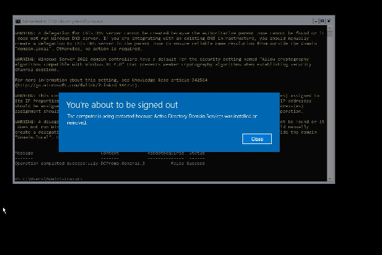

Active Directory is installed

2. Confirm im in a domain

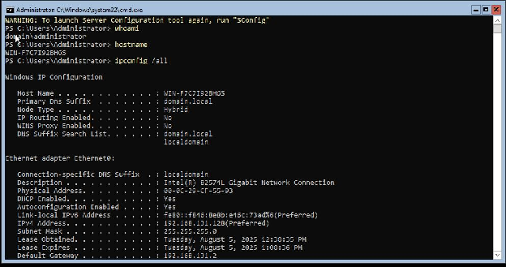